# BiodiversidadGJC

Juan Carlos García Estupiñán

# 1 **Número de puntos de especies clasificadas a partir de las fotografías en el mapa**

| **Organismos** | **Nº CLASIFICADAS** |
| --- | --- |
| *Animales* | 141 |
| *Plantas* | 1698 |

# 2 **Estadísticas de los organismos**

## 2.1 Número de especies de Metazoos y Plantas Clasificadas:

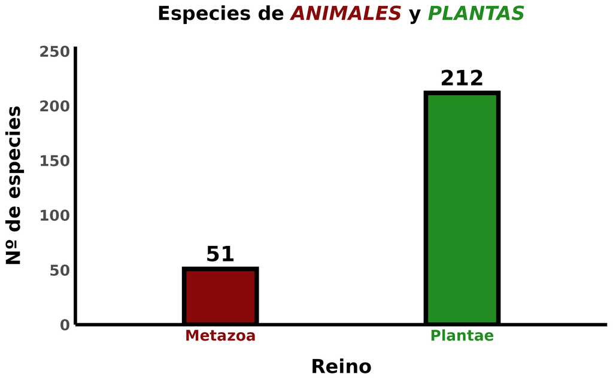

## 2.2 Tabla de la endemicidad de las especies de plantas y animales identificadas:

**Endemicidad de los organismos (Canarias) según: género, especie y subespecie**

|  | Géneros NO | Géneros SI | Especies NO | Especies SI | Subespecies NO | Subespecies SI |
| --- | --- | --- | --- | --- | --- | --- |
| Metazoa | 48 | 3 | 38 | 13 | 0 | 4 |
| Plantae | 202 | 11 | 123 | 90 | 4 | 2 |

## 2.3 Especies categorizadas según su *origen* y *protección*:

### 2.3.1 Gráfico para las especies de animales:

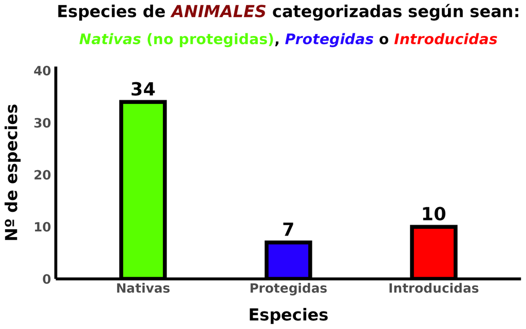

### 2.3.2 Gráfico para las especies de plantas:

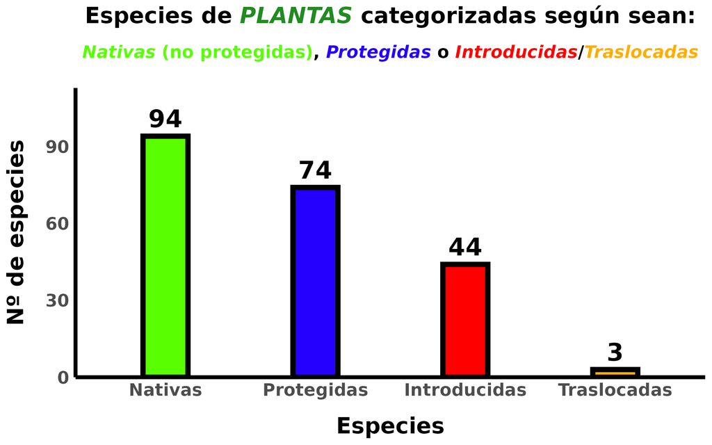

# 3 **Número de especies por isla**

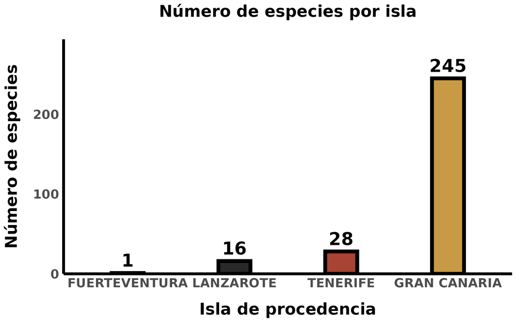

## 3.1 Número de especies de animales y plantas por isla

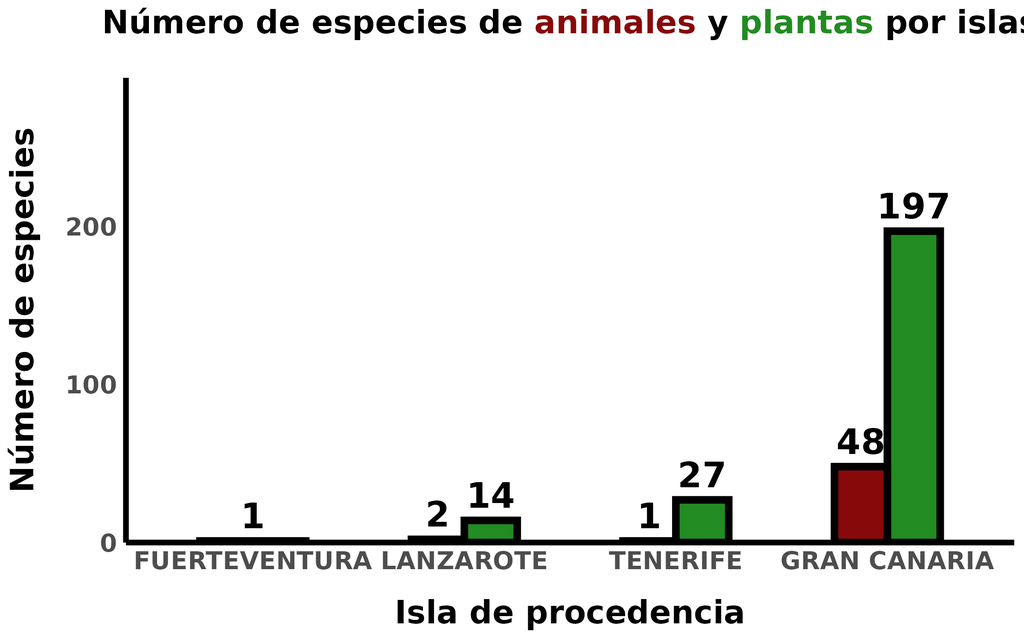

# 4 **Espacios Protegidos**

En esta base de datos se guarda información de especies que aparecen en la *Red de Espacios Naturales Protegidos* (**ENP**) de Canarias, así como de las *Zonas de Especial Conservación* (**ZEC**) de la **Red Natura 2000**.

## 4.1 Porcentaje de Especies que he observado en ENP y fuera de ellos:

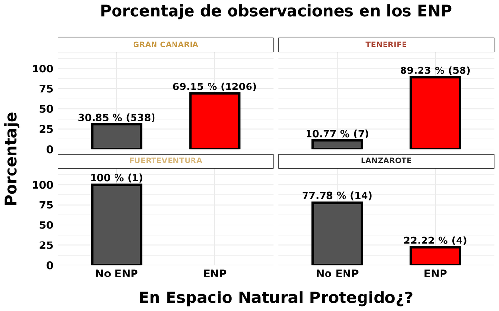

### 4.1.1 Estudio detallado de las especies en los ENP de *Gran Canaria*

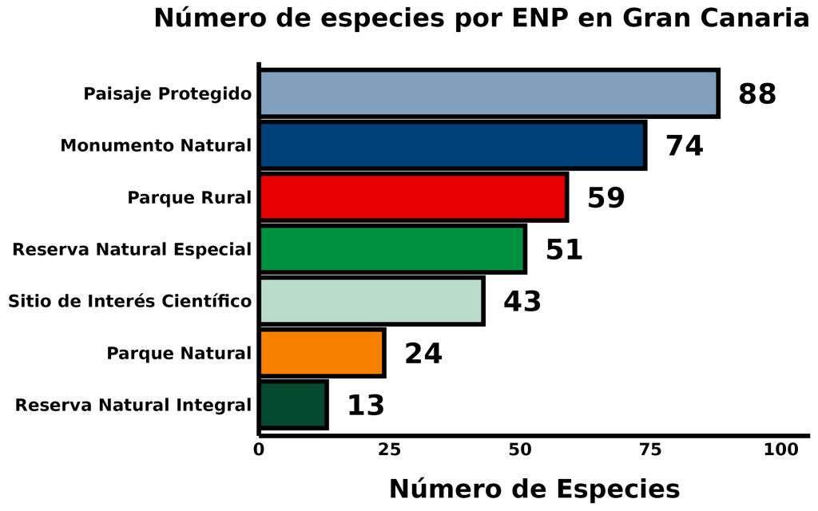

**De la información anterior, me interesa saber los sitios en concreto de estos ENP en los que he encontrado especies.**

Esta información se encuentra en el siguiente gráfico, en el que recomiendo pulsar para ver zoom:

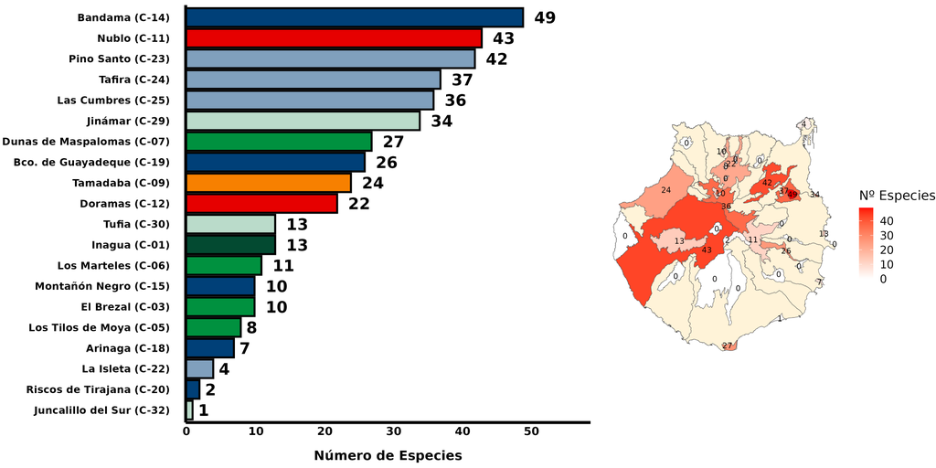

## 4.2 Zonas de Especial Conservación

En Canarias hay zonas de conservación, que son áreas protegidas determinadas por la Unión Europea.

### 4.2.1 Isla de Gran Canaria

En este apartado, muestro las estadísticas de mis especies en cada zona de La isla.

Se trata de la mi Isla de procedencia, por lo que es en la cuál tengo más observaciones. Como en el gráfico de los ENP, recomiendo pulsar el zoom para ver mejor los datos:

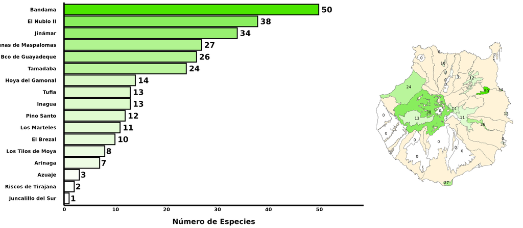